# Hunger in America is a Policy Crisis

Mark Hamer

May 3, 2026

## Introduction

47 million Americans faced food insecurity in 2023. That is 1 in 7 households. This report is not about hunger in developing countries. It is about hunger here. In every state. In working families.

The United Nations tracks food insecurity as a global crisis. The data shows it is also a domestic one. The difference is that in America, hunger is not caused by drought or war. It is caused by policy. Specifically, a nutrition assistance system that was designed with a hard cutoff that punishes families for earning more.

This report makes three arguments. First, food insecurity in America is concentrated but universal. No state is fully exempt. Second, a large portion of the people who go hungry are largely working people who earn too much to qualify for help but too little to afford food. Third, the gap between what SNAP provides and what adequate nutrition costs is large enough to matter and small enough to fix.

The data comes from Feeding America, the USDA, and the U.S. Census Bureau.

## Where Hunger Happens

Food insecurity is not evenly distributed. Some states are significantly worse than others. The map below shows food insecurity rates by state using 2023 data. The concentration in the South is not random. It reflects decades of lower wages, weaker labor protections, and higher poverty rates in that region.

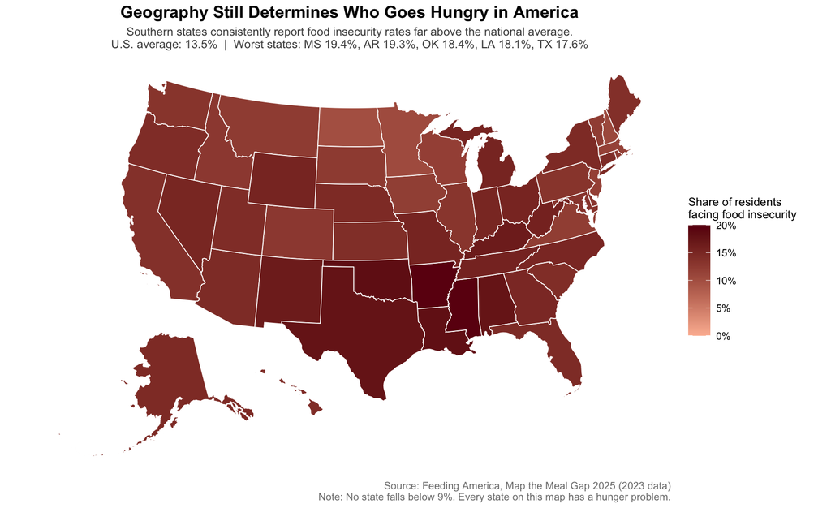

Mississippi, Arkansas, Oklahoma, Louisiana, and Alabama all exceed 17%. North Dakota is the lowest at 9.9%. Every single state is above 9%. There is no state where hunger is not a problem.

## Who Hunger Affects

Food insecurity does not affect everyone equally. Some groups face it at rates far above the national average. Understanding who is most affected is the first step to understanding why the system fails them. The chart below breaks down food insecurity rates by age group and household type using 2023 national data.

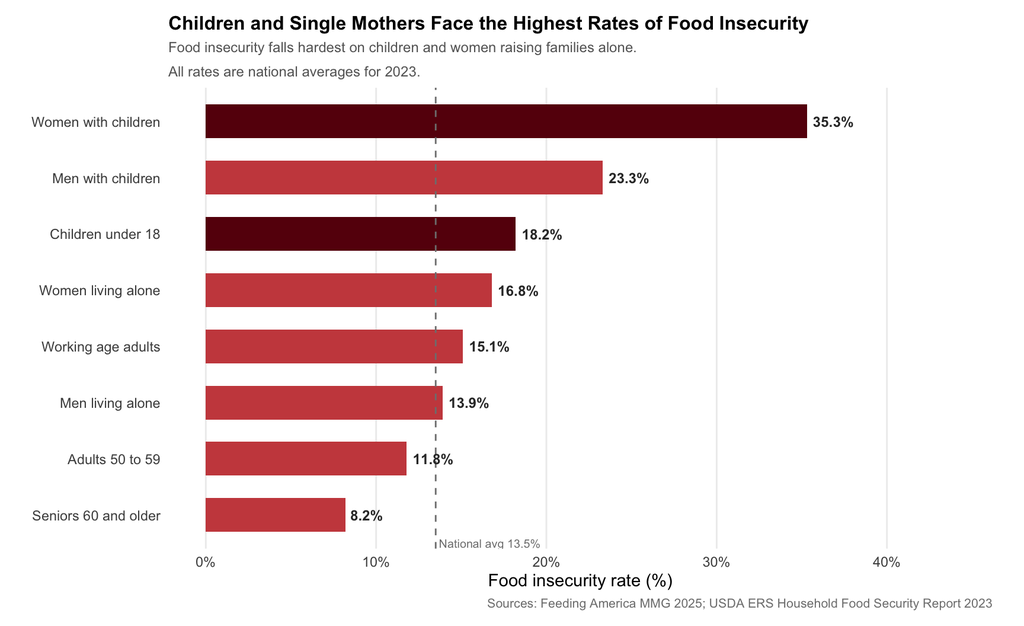

Women raising children alone face a 35.3% food insecurity rate. That is more than 1 in 3 households. Children under 18 face an 18.2% rate. Seniors face the lowest rate at 8.2%, partly because Social Security and Medicare provide more stable support than SNAP does for working age adults.

The child rate matters most for what comes next. Food insecurity in childhood does not stay in childhood. It follows children into adulthood through lower educational attainment, worse health outcomes, and lower earnings. The chart below shows that progression.

A food insecure child is more likely to fall behind in school, less likely to graduate, more likely to face chronic illness, and more likely to be food insecure as an adult. This is not a temporary hardship that resolves itself. It is a cycle that the current system reproduces.

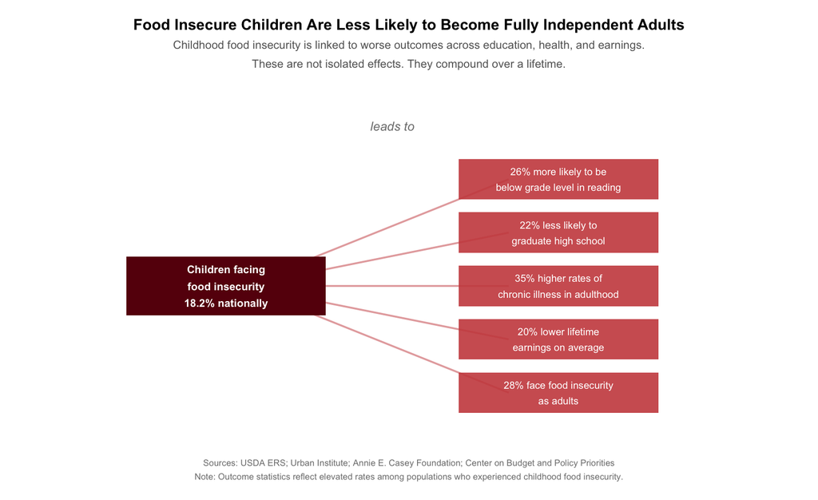

This brings us to the structural question. If these outcomes are predictable and measurable, why does the system continue to produce them? The answer is in how SNAP is designed, who it covers, and how much it provides. The charts that follow show each of those failures in turn.

## Why It Happens

The map shows where hunger is worst. This chart shows why. States with higher poverty rates consistently have higher food insecurity rates. This is not a coincidence. It is a structural relationship. When families cannot afford basic expenses, food is often the first thing that gets cut. Each point on the chart below is a state. The line shows the national trend.

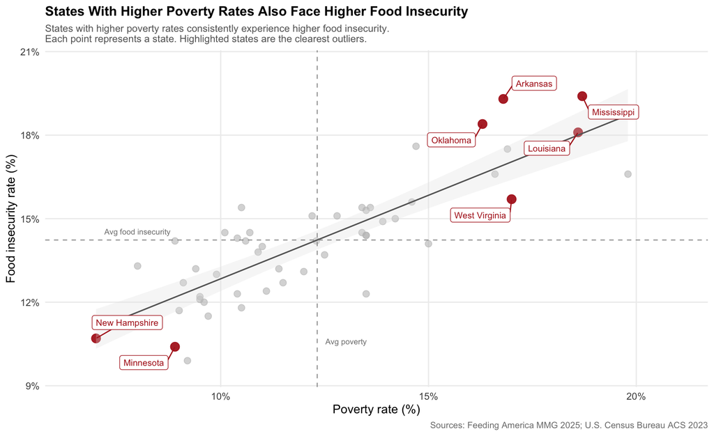

New Mexico has a 19.8% poverty rate and a 16.6% food insecurity rate. New Hampshire has a 7% poverty rate and a 10.7% food insecurity rate. The relationship holds across every region. Poverty and hunger move together. Any serious attempt to reduce food insecurity has to address the economic conditions that create it.

## What Adequate Nutrition Actually Costs

The USDA publishes a monthly cost estimate for the cheapest diet that still meets nutritional guidelines. It is called the Thrifty Food Plan. It assumes all meals are cooked at home and represents the absolute floor of adequate nutrition. The chart below compares what that costs for four common household types against what the average SNAP benefit actually provides.

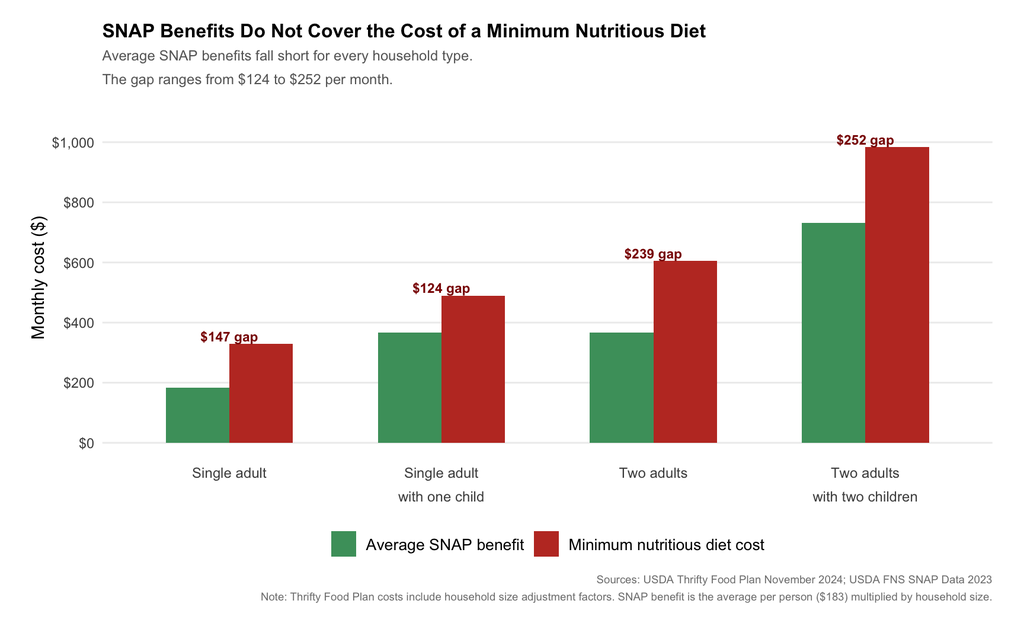

The average SNAP benefit falls short for every household type. A single adult receives an average of $183 per month but needs $330 to meet the minimum nutrition standard. A family of four receives $732 on average but needs $984. The gap ranges from $124 to $252 per month depending on household size. These are not large numbers in the context of a federal budget. They are very large numbers for a family trying to eat.

## Who Actually Goes Hungry

Food insecurity is often assumed to affect people who do not work. The data does not support that assumption. The chart below shows food insecurity rates by income level. People below the poverty line face the highest rates. But people above the poverty line who do not qualify for SNAP face a 28% food insecurity rate. That is nearly double the national average. They earn too much for help. They do not earn enough to eat.

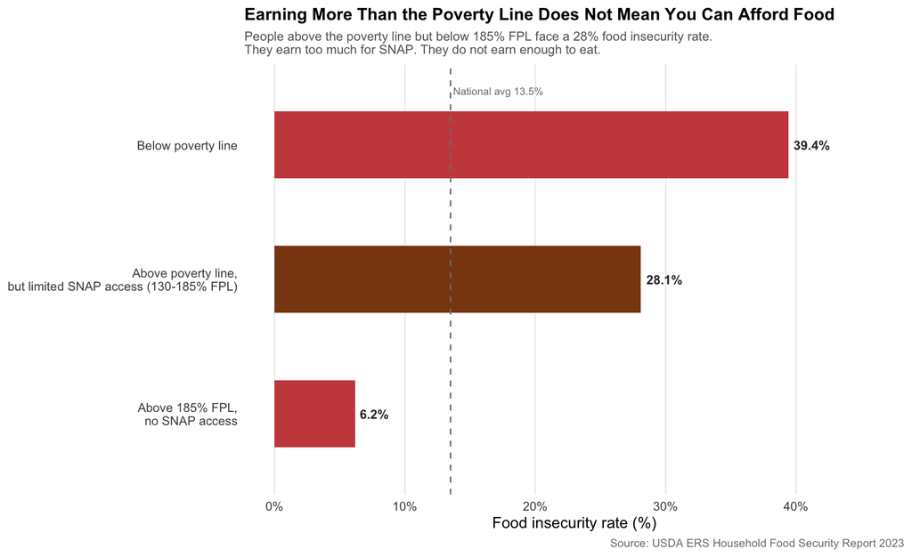

This group is sometimes called the working poor. They are employed. They pay taxes. They do not qualify for SNAP because their income exceeds 130% of the federal poverty line. In 2025 that cutoff is $20,345 for a single person. A person earning $21,000 per year gets no SNAP assistance. They also cannot afford adequate nutrition on that income in most parts of the country.

## The System Punishes Earning More

[figure not shown]

## What a Better System Could Look Like

The cliff effect is not inevitable. It is a product of a binary eligibility threshold. Benefits either exist at full value or they disappear. A gradual phase-out model would reduce benefits slowly as income rises rather than eliminating them at a single cutoff point. The chart below shows the same $1,000 raise scenario under a gradual phase-out model for each household size.

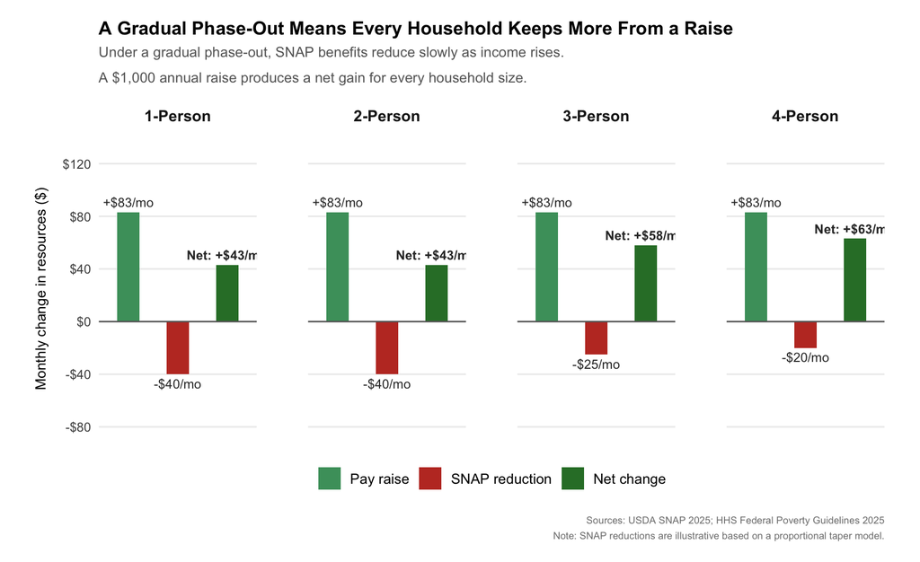

Under a gradual phase-out, a $1,000 raise produces a net gain for every household size. The benefit reduction is smaller and the family keeps more of what they earn. This is not a radical proposal. It is how most phase-out programs in other countries are structured. It preserves work incentives without eliminating support for families who still need it.

## What Reform Would Look Like at the National Level

The opening map showed food insecurity as it exists today. The maps below show today alongside a projected outcome if SNAP benefits were expanded to meet the Thrifty Food Plan minimum cost. The projection applies a conservative 20% reduction in food insecurity rates based on research linking adequate benefit levels to improved outcomes. Both maps use the same color scale.

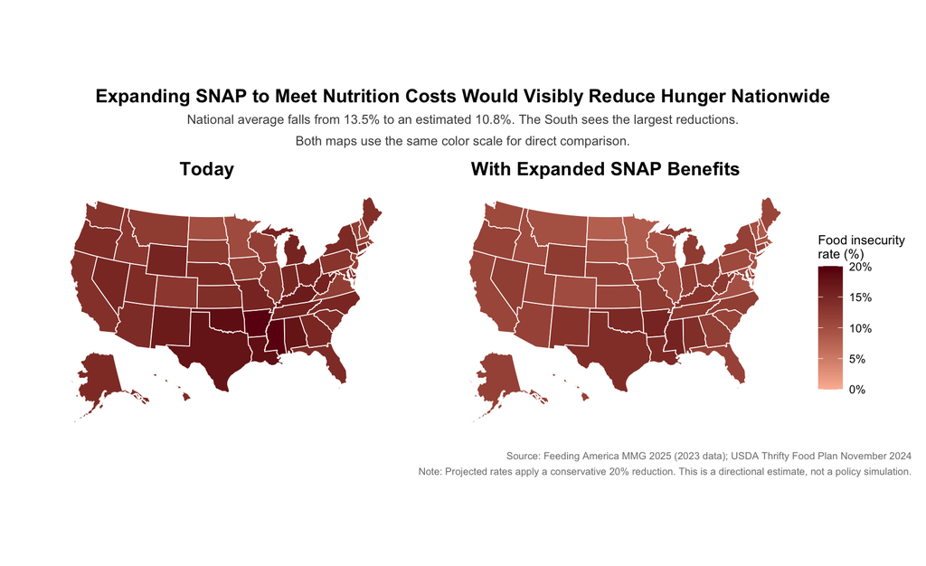

## Conclusion

Hunger in America is not a scarcity problem. The food exists. The system to distribute it exists. What does not work is the policy that determines who gets help and how much.

Three changes would make a measurable difference. First, increase SNAP benefits to meet the Thrifty Food Plan minimum cost. The gap is between $124 and $252 per month depending on household size. Second, replace the hard eligibility cutoff with a gradual phase-out that reduces benefits slowly as income rises. Third, index benefit levels to regional food costs so families in high cost states are not penalized for where they live.

None of these changes require a new program. They require adjustments to one that already exists. The national food budget shortfall, the total additional dollars food insecure Americans need to meet minimum nutrition costs, is $22.6 billion per year according to Feeding America. That is less than 0.3% of the federal budget.